# Technical note: Amorphous track model with Libamtrack

Lia Valdetaro

4/13/20

```r
library(libamtrack)
require(lattice)
```

## Introduction

We can describe the dosimeter in the framework of Katz’s track structure theory as consisting of initially inactive targets, which become activated after one or many hits . The ionizing radiation traveling through the radiochromic dosimeter produces a local concentration of free radicals along its path; these are mostly originated from the chloroform, although a small percentage may come from free silicone elastometer chains . A detector system consists of a sensitive spherical active element (targets), embedded in a passive matrix. Radiation can inactivate targets if at least a certain number of hits occur (a hit is an event in which an energy larger or equal the minimum required energy $E_{min}$ is deposited in the target). Considering that the assumption of Poisson distributed hits is correct, the probability of exactly $n$ hits after an applied dose of D is
$$\begin{equation}
P(n) = \frac{(vD)^n e^{-vD}}{n!},
\end{equation}$$
where $vD$ is the average number of hits, and $v$ is the target volume measured in hits per gray.

Multi-hit detectors are those whose targets requine $n$ hits to be activated; targets with $n-1$ or less hits are not affected. If $N$ is the number of affected targets and $N_0$ the total number of tagets, we can express the fraction of affected targets as the sum over all targets receiving less than $n$ hits:
$$\begin{equation}
\frac{N(D)}{N_0} = 1- e^{-vD}\sum_{k=0}^{n-1}\frac{(vD)^k}{k!}.
\end{equation}$$
Generalizing from multi-hit to multi-target detectors (effect occurs if $m$ targets receive at least $n$ hits), we have
$$\begin{equation}\label{eq7}
\frac{N(D)}{N_0} =\bigg(1- e^{-vD}\sum_{k=0}^{n-1}\frac{(vD)^k}{k!}\bigg)^m.
\end{equation}$$
Multi-hit detectors have supra-linear dose response, which in particle beams can lead to a relative effectiveness larger than unity.Multitarget detectors can potentially mimic the response of cells.

## Track structure calculations - libamtrack code

### Dosimeter gamma response

It is reasonable to assume that the detector response will be directly proportional to the number of hits. Therefore, given a maximum response $OD_\textrm{max}$, for a one-hit detector, we find:
$$\begin{equation}\label{eq8}
P_1 = 1-e^{-D/D_1},
\end{equation}$$
and for a two-hit detector:
$$\begin{equation}\label{eq9}
P_2 = 1-\bigg(1+\frac{D}{D_2}\bigg)e^{-D/D_2}.
\end{equation}$$
To find in which category the detector falls into, we look into its saturation curve with $\gamma$-irradiation; neither of the curves above completely match the correct behavior at all doses; equation is linear at low and sub-linear at high doses, while equation follows a sigmoid at low and is supra-linear at high doses. Rather, it is a mixture of both one- and two-hit detectors:
$$\begin{equation}\label{eq10}
\frac{OD_\gamma(D)}{OD_\gamma^\textrm{max}} = r P_1 + (1-r)P_2,
\end{equation}$$
where $r$ is the fraction that the one-hit component contributes. The parametrization of $(OD_\gamma^\textrm{max}, \, r, \,E_1, \,E_2)$ is found by fitting the equation above to the data points, using the generalized hit/target model with $n=1, \,m=1$ and $n=2, \, m=1$.

```python
import numpy as np
import matplotlib.pyplot as plt
import math
from scipy.optimize import curve_fit

def dummy_model():
    # generates the data points from EM parametrization - temporary
    a = 3.61
    b = 0.38
    c = 2.5 * 10 ** 3
    d = 2.1 * 10 ** 6

    curve = np.linspace(0, 10, num=16)
    supralin = np.linspace(0, 10, num=16)
    i = 0
    D = 10
    D0 = a * (b * (1 - math.exp(-D / c)) + (1 - b) * (1 - math.exp(-D ** 2 / d)))
    d_array = np.array([20, 50, 100, 110, 120, 150, 200, 500, 900, 1200, 2000, 2500, 5000, 7000, 10000, 10500])
    for D in d_array:
        y = a * (b * (1 - math.exp(-D / c)) + (1 - b) * (1 - math.exp(-D ** 2 / d)))
        curve[i] = y
        supralin[i] = y / (D0 / 10) / D
        i = i + 1

    return curve, d_array


def saturation_fit(x, a, b, c, d):
    return np.log(a * (b * (1 - np.exp(-np.divide(x, c))) + (1 - b) * (1 - (1 + x / d) * np.exp(-np.divide(x, d)))))


def main():
    data_points, dose = dummy_model()  # gamma saturation curve
    popt, pcov = curve_fit(saturation_fit, dose, np.log(data_points), bounds=([1, 0, 2000, 900],[1000, 1, 3000, 1000]))

    print('fit parameters: ', popt)


if __name__ == "__main__":
    main()
```

```
fit parameters:  [3.75206289e+00 2.69730098e-01 2.00000000e+03 9.00000000e+02]
```

Once we have the parameters from a fit to the experimental data (above), we can set the gamma response curve with libamtrack using the function **AT.gamma.response**. The gamma model chosen (*gamma.model=2*) corresponds to the general hit(target model described in the equations above.

```r
    d.Gy                    <- 10^seq(from = log10(0.1), to = log10(10^5), length.out = 5000)
    gamma.model     <- 2
    R           <- 27
    Smax        <- 3.75
    k1          <- Smax * (R / 100)
    k2          <- Smax * (1 - R / 100)
    gamma.parameter.peak.A  <- c( k1 = k1, D01 = 2.0*10^3, c1 = 1, m1 = 1,
                                k2 = k2, D02 =9.00*10^2, c2 = 2, m2 = 1, 0)

    vecA <- AT.gamma.response( d.Gy              = d.Gy,
                                gamma.model       = gamma.model,
                                gamma.parameter   = gamma.parameter.peak.A,
                                lethal.event.mode = FALSE)$response

    cat(vecA, file = "saturation_curve_OC.txt", append = FALSE, sep = "\t")
    cat(d.Gy, file = "saturation_curve_Dose.txt", append = FALSE, sep = "\t")
```

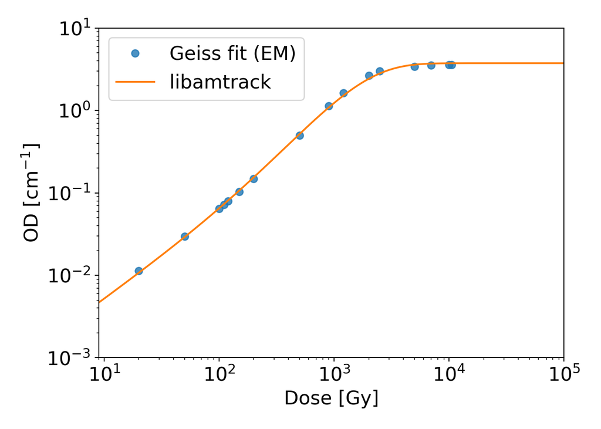